# Descripción de la Base de Datos ENPOL 2021 a Travez del Análisis de Componentes Principales

Universidad Nacional de Colombia

Yudy Vanesa Puerres Rosero (ypuerresr@unal.edu.co)

Camila Andrea Ayala Camargo (caayala@unal.edu.co)

Karen Liliana Barrantes Quiroga (kbarrantes@unal.edu.co)

Laura Katherine Martínez Castiblanco (laumartinezca@unal.edu.co)

Fredy Arley Urrea Cifuentes (furreac@unal.edu.co)

# Descripción de la base de datos ENPOL 2021

Para este proyecto utilizo la **Encuesta Nacional de la Población Privada de la Libertad (ENPOL)** correspondiente al año **2021**, la cual es una operación estadística desarrollada por el Instituto Nacional de Estadística y Geografía (INEGI) de México. Esta encuesta constituye una de las fuentes más completas y actualizadas sobre las condiciones de vida, características sociodemográficas y situación jurídica de las personas privadas de la libertad en el país.

La ENPOL tiene como objetivo generar información confiable sobre diferentes aspectos del internamiento, tales como el acceso a servicios básicos, el nivel de hacinamiento, los antecedentes familiares y laborales de la población reclusa, y la experiencia que las personas han tenido dentro del sistema penitenciario. Esta encuesta se ha aplicado en dos ocasiones, en 2016 y 2021; para este trabajo utilizo los datos más recientes.

En general, la ENPOL incluye una amplia variedad de temas: desde variables sociodemográficas hasta condiciones específicas del internamiento, percepciones de seguridad, reincidencia, vínculos familiares y características del centro penitenciario. En este proyecto se trabajó con un subconjunto de estas variables, las cuales fueron:

Diccionario de Variables del Estudio

| variable | definicion | tipo |
| --- | --- | --- |
| id_persona | Identificador único del participante | Categórica (ID) |
| edad | Años cumplidos al momento de la encuesta | Cuantitativa |
| estado_civil | Estado civil recodificado en 4 categorías | Categórica |
| escolaridad | Nivel educativo agrupado en 4 niveles | Categórica ordinal |
| tiene_hijos | Indica si el participante tiene hijos | Dummy |
| numero_hijos | Número total de hijos | Cuantitativa |
| mantiene_alguien | Mantenía económicamente a alguien antes de la detención | Dummy |
| personas_celda | Número de personas con quienes comparte celda | Cuantitativa |
| comida_dia | Número de comidas proporcionadas al día | Cuantitativa |
| horas_celda | Horas que pasa en la celda durante un día | Cuantitativa |
| seguridad_celda | Percepción de seguridad en la celda | Dummy |
| antes_recluido | Ha sido recluido previamente | Dummy |
| veces_recluido | Número total de reclusiones previas | Cuantitativa |
| vivio_con_madr | Vivió con su madre antes de los 15 años | Dummy |
| vivio_con_padr | Vivió con su padre antes de los 15 años | Dummy |
| mujer | Dummy: 1 si es mujer | Dummy |
| detencion_varo | Dummy: 1 si el centro es varonil | Dummy |
| detencion_fem | Dummy: 1 si el centro es femenil | Dummy |

La base de datos original cuenta con 61.449 personas entrevistadas, a quienes se les aplicó un cuestionario de 1.252 variables. Dado el volumen y la naturaleza de la información (mayoritariamente dicotómica y con opciones adicionales como “no sé” o “no respondo”) es ideal aplicar un Análisis de Componentes Principales (ACP) que permita sintetizar y describir mejor la estructura subyacente de los datos.

Sin embargo, para los fines de este proyecto (y dado a limitaciones computacionales) se seleccionó un subconjunto de 17 variables relacionadas con características sociodemográficas, condiciones de internamiento y antecedentes personales. Durante la revisión inicial se identificó que varias preguntas no eran respondidas por motivos lógicos. Por ejemplo, quienes indicaban no tener hijos dejaban en blanco el número de hijos; en estos casos se imputó el valor 0, coherente con el contexto.

Tras este ajuste, el volumen restante de datos faltantes resultó mínimo en relación con el tamaño total de la muestra, por lo que se optó por eliminar los registros con respuestas vacías o con las opciones “No sabe/No responde”.

Además, dado que el ACP requiere trabajar exclusivamente con variables cuantitativas, se transformaron en dummies todas las variables dicotómicas, y la variable sobre el tipo de centro penitenciario (femenil, varonil o mixto) se recodificó en dos variables dummy adicionales.

Por lo tanto, el análisis se realizó sobre una base de 31.535 individuos y 18 variables, donde una corresponde al identificador, dos son categóricas transformadas en dummies y el resto son completamente cuantitativas.

Pero antes de proceder con el ACP se hace una breve descripción y análisis de los datos por histogramas y gráficos de barras, antes de pasar a dummy las variables dicotomicas.

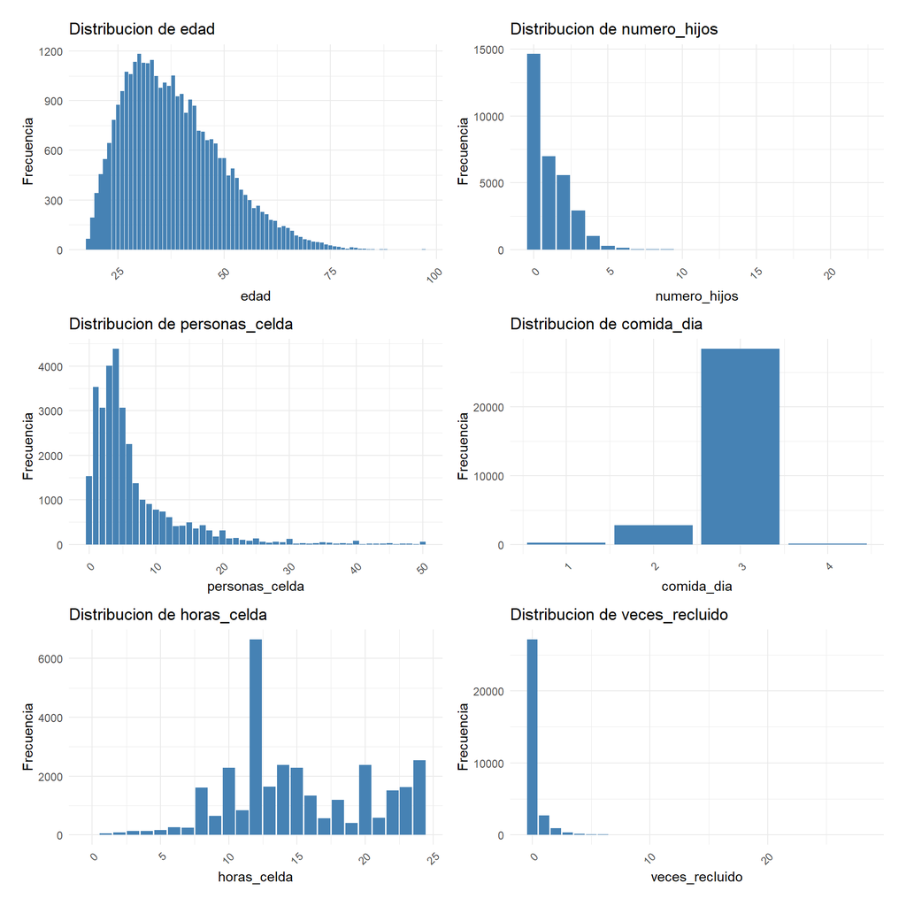

En conjunto, estas distribuciones permiten identificar desigualdades en las condiciones de vida dentro de los centros penitenciarios y evidencian la heterogeneidad de experiencias entre los entrevistados

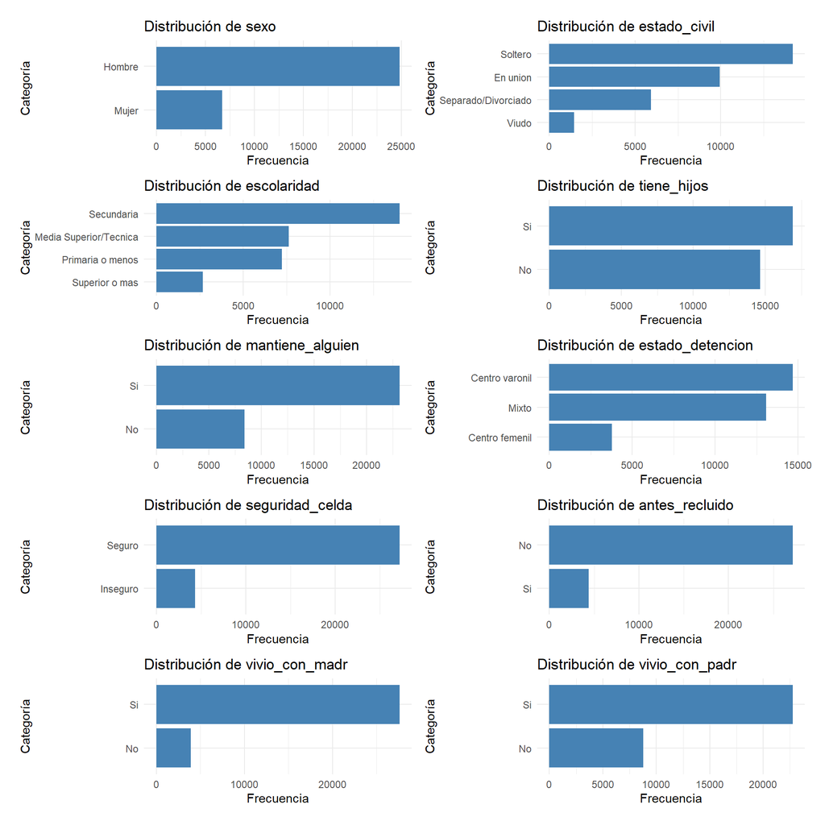

Se observa que predominan los hombres en las carceles de México, así como personas solteras y con niveles educativos que no superan la secundaria. Más de la mitad declara tener hijos y una proporción importante mantenía económicamente a alguien antes de su detención, lo que evidencia que el encarcelamiento afecta no solo al individuo, sino también a su entorno familiar. Estas condiciones sociales y educativas reflejan patrones de vulnerabilidad que suelen documentarse en población penitenciaria.

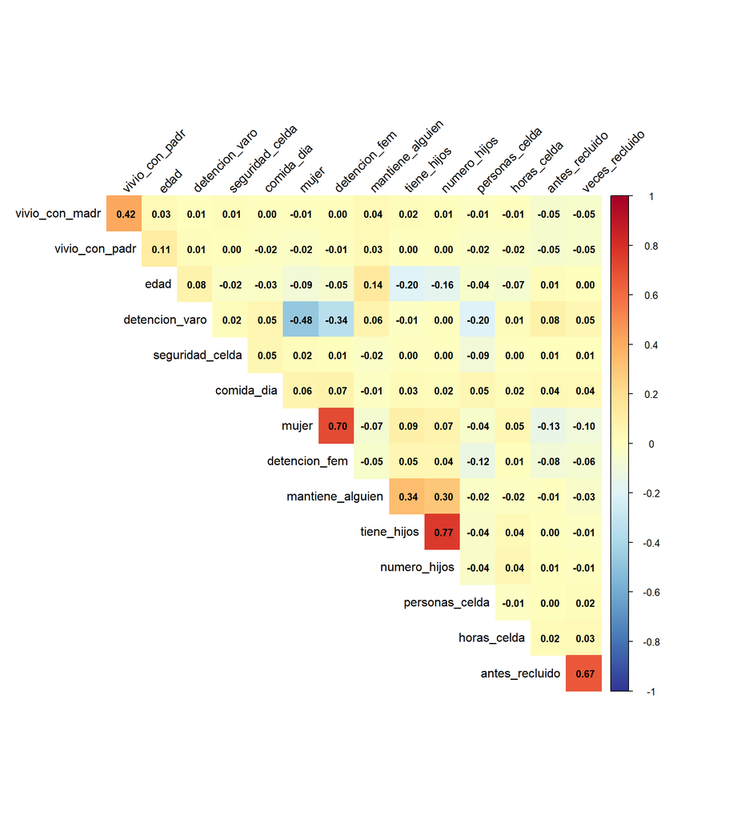

Por otra parte, las variables asociadas a antecedentes penales, como haber sido recluido previamente y número de reclusiones, presentan correlaciones esperables, mientras que factores del entorno familiar en la niñes muestran asociaciones débiles con el resto de los indicadores.

# Análisis de Componentes Principales (ACP)

```r
res.pca<-FactoMineR:: PCA(vars_cont, scale.unit = TRUE, ncp = 20, graph = FALSE)
acp <- dudi.pca(vars_cont, scannf = FALSE, nf = 15)

# El parámetro nf indica cuantos ejes voy a conservar
valp <- t(inertia(acp)$tot.inertia) # valores propios
#kable(valp, digits = 3)
```

en donde se sabe que

- Varianza de la componente $\alpha$:
  $$\text{var}(z_\alpha) = \lambda_\alpha$$
- Porcentaje de varianza explicada por la componente $\alpha$:
  $$\tau_\alpha = \frac{\lambda_\alpha}{\sum_{\alpha=1}^p \lambda_\alpha}$$
- Porcentaje acumulado de varianza explicada por las primeras $q$componentes:
  $$\tau_q = \frac{\sum_{\alpha=1}^q \lambda_\alpha}{\sum_{\alpha=1}^p
  \lambda_\alpha}$$

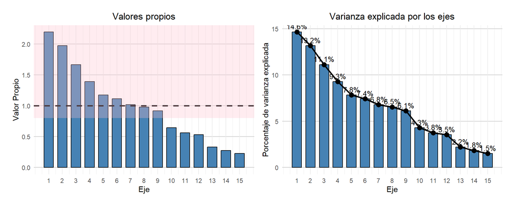

## Contribuciones de las Variables a la Varianza del Factor

$$\text{Contribución}(Y_j, z_\alpha) = \frac{u_{j\alpha}^2 \cdot
\lambda_\alpha}{\lambda_\alpha} = u_{j\alpha}^2$$
O, en forma de porcentaje:
$$\text{Contribución}(\%) = \frac{u_{j\alpha}^2}{\sum_{j=1}^p
u_{j\alpha}^2} \times 100$$

Interpretación: - Indica cuánto contribuye la variable $Y_j$a la formación de la componente $z_\alpha$. - Valores altos: La variable es importante para definir esa componente.

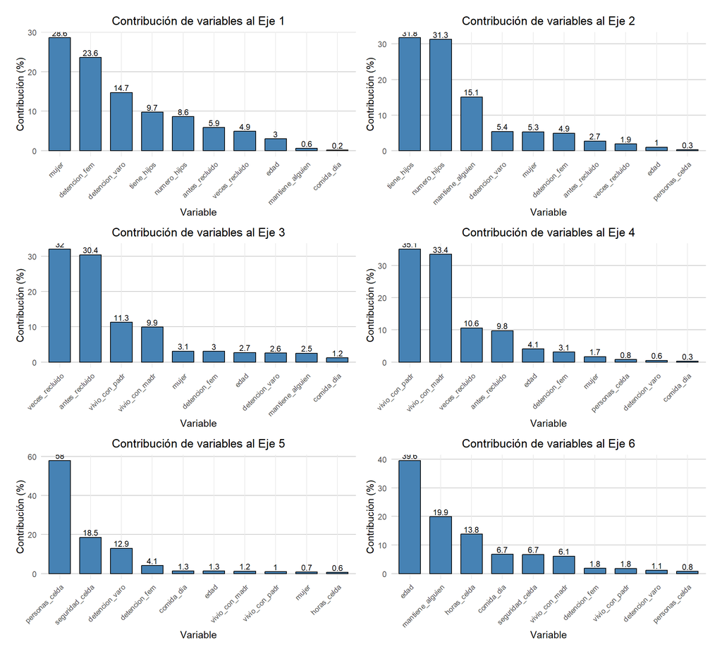

## Cosenos Cuadrados ($\cos^2$)

$$\cos^2(\theta_{j,\alpha}) = \lambda_\alpha \cdot u_{j\alpha}^2$$

Interpretación: - Representa la proporción de la varianza de la variable $Y_j$que es explicada por la componente $z_\alpha$. - Valores altos: La variable está bien representada en esa componente.

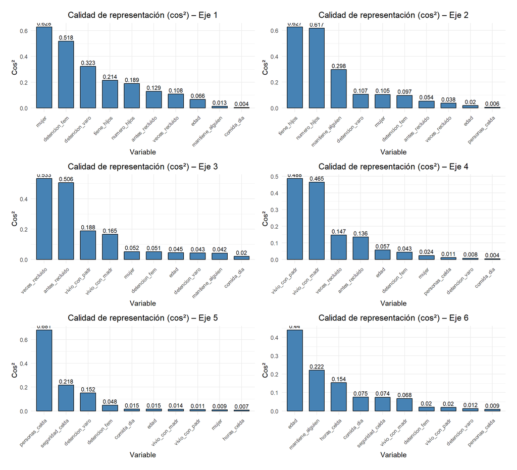

## Coordenadas de los Objetos (Individuos)

$$z_{i\alpha} = \sum_{j=1}^p u_{j\alpha} \cdot y_{ij}$$
o, en notación matricial:
$$z_\alpha = Y \cdot u_\alpha$$

Interpretación: - Representa la posición del objeto $i$en la componente $\alpha$. - Se usan para graficar los objetos en los planos factoriales.

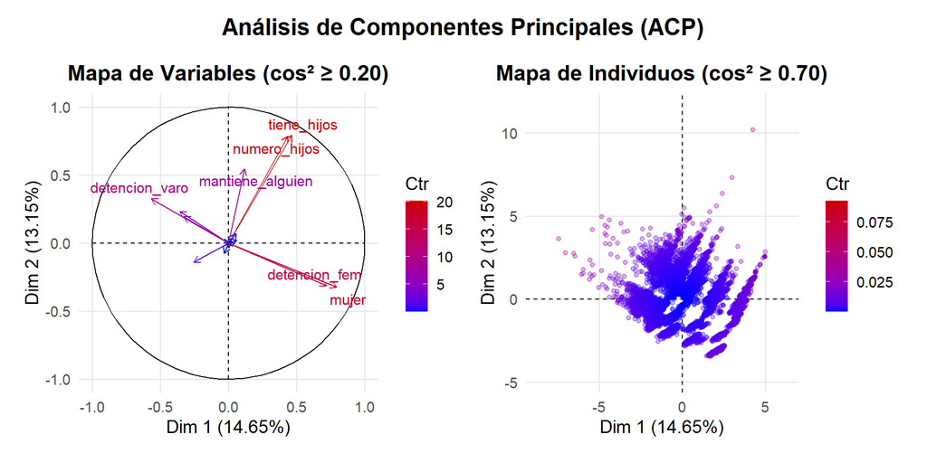

```r
# ---------- GRÁFICO 1: VARIABLES ----------
g1 <- plot.PCA(
  res.pca,
  choix = "var",
  select = "cos2 0.2",
  unselect = 0,
  habillage = 'contrib',
  label = "all"
) +
  ggtitle("Mapa de Variables (cos² ≥ 0.20)") +
  theme_minimal(base_size = 14) +
  theme(
    plot.title = element_text(face = "bold", hjust = 0.5),
    panel.grid.minor = element_blank()
  )

# ---------- GRÁFICO 2: INDIVIDUOS ----------
g2 <- plot.PCA(
  res.pca,
  choix = "ind",
  invisible = c("ind.sup"),
  select = "cos2 0.7",
  habillage = 'contrib',
  label = "none"
) +
  ggtitle("Mapa de Individuos (cos² ≥ 0.70)") +
  theme_minimal(base_size = 14) +
  theme(
    plot.title = element_text(face = "bold", hjust = 0.5),
    panel.grid.minor = element_blank()
  )

g_final <- g1 + g2 +
  plot_annotation(
    title = "Análisis de Componentes Principales (ACP)",
    theme = theme(
      plot.title = element_text(size = 18, face = "bold", hjust = 0.5)
    )
  )
g_final
```

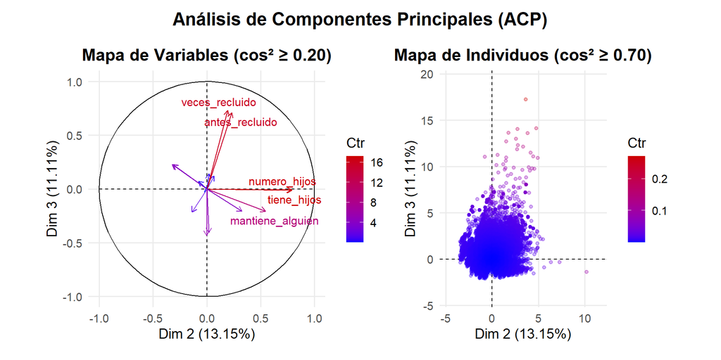

[figure not shown]

[figure not shown]

```r
# ---------- GRÁFICO 1: VARIABLES ----------
g1 <- plot.PCA(
  res.pca,
  choix = "var",
  axes=c(2,3),
  select = "cos2 0.2",
  unselect = 0,
  habillage = 'contrib',
  label = "all"
) +
  ggtitle("Mapa de Variables (cos² ≥ 0.20)") +
  theme_minimal(base_size = 14) +
  theme(
    plot.title = element_text(face = "bold", hjust = 0.5),
    panel.grid.minor = element_blank()
  )

# ---------- GRÁFICO 2: INDIVIDUOS ----------
g2 <- plot.PCA(
  res.pca,
  choix = "ind",
  axes=c(2,3),
  invisible = c("ind.sup"),
  select = "cos2 0.7",
  habillage = 'contrib',
  label = "none"
) +
  ggtitle("Mapa de Individuos (cos² ≥ 0.70)") +
  theme_minimal(base_size = 14) +
  theme(
    plot.title = element_text(face = "bold", hjust = 0.5),
    panel.grid.minor = element_blank()
  )

g_final <- g1 + g2 +
  plot_annotation(
    title = "Análisis de Componentes Principales (ACP)",
    theme = theme(
      plot.title = element_text(size = 18, face = "bold", hjust = 0.5)
    )
  )
g_final
```

## Variables Suplementarios

- Proyección de variable suplementaria:
  $$Y^+ \cdot u_\alpha$$

Interpretación: - Permiten incluir información adicional sin afectar el cálculo de las componentes. - Cercanía a variables/objetos activos: Indica similitud o asociación.

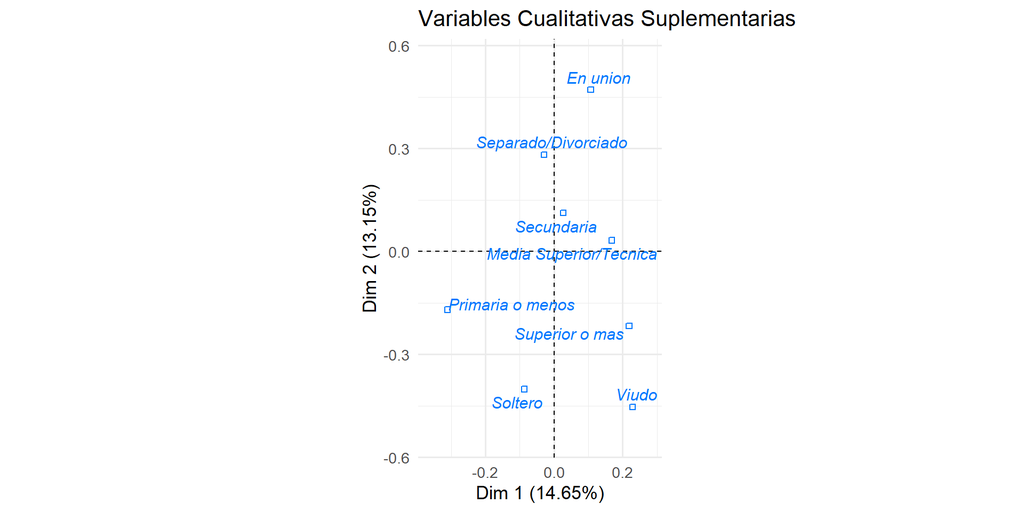

```r
res.PCA<-PCA(datos_con_dummies %>% select(-id_persona),quali.sup=c(2,3),graph=FALSE,  scale.unit = TRUE)

# ---- Variables suplementarias ----
plot.PCA(
  res.PCA,
  invisible = c("ind", "ind.sup"),
  col.quali = "#0077FF",
  label =c('quali')
) +
  ggtitle("Variables Cualitativas Suplementarias") +
  theme_minimal(base_size = 13)
```

```r
# Crear muestra del 10%
muestra_10pct <- datos_con_dummies %>%
  sample_frac(0.10)
nrow(muestra_10pct) # 3 154
# 1. ACP estándar
result <- PCAshiny(muestra_10pct %>% select(-id_persona))
```